# Working Carers in the United Kingdom

June 2021

## Method

A people database was searched for a talent pool that matched the following criteria:

Women who live in the UK and are >45 years old (born before 1975, have over 20 years work experience, or graduated college earlier than 1997) and are senior managers or lower. This resulted in over 1 million records, which were subsequently analyzed for informative insights.

## Results

### Top 20 Industries

Using the industry of each worker’s last recorded experience, the top industries were identified.

| COMPANY_INDUSTRY | Relative Frequency |
| --- | --- |
| government administration | 7% |
| hospital & health care | 6% |
| financial services | 6% |
| retail | 6% |
| information technology and services | 4% |
| banking | 4% |
| higher education | 3% |
| education management | 3% |
| law practice | 2% |
| non-profit organization management | 2% |
| telecommunications | 2% |
| accounting | 2% |
| insurance | 2% |
| leisure, travel & tourism | 2% |
| pharmaceuticals | 2% |
| hospitality | 2% |
| staffing and recruiting | 1% |
| oil & energy | 1% |
| marketing and advertising | 1% |
| construction | 1% |

### Top 10 Companies from the top 20 Industries

|  | COMPANY_INDUSTRY | COMPANY_NAME | Relative Frequency |
| --- | --- | --- | --- |
| 1 | accounting | pwc | 25% |
| 2 | accounting | ey | 12% |
| 3 | accounting | kpmg uk | 5% |
| 4 | accounting | kpmg | 3% |
| 5 | accounting | bdo uk llp | 2% |
| 6 | accounting | grant thornton uk llp | 2% |
| 7 | accounting | audit commission | 2% |
| 8 | accounting | arthur andersen &amp; co. | 2% |
| 9 | accounting | grant thornton llp | 1% |
| 10 | accounting | rsm uk | 1% |

[output cut: 192 more lines]

### Top Industries and Companies by Number of Working Carers

|  | COMPANY_INDUSTRY | COMPANY_NAME | Number |
| --- | --- | --- | --- |
| 1 | accounting | pwc | 3025 |
| 2 | accounting | ey | 1429 |
| 3 | accounting | kpmg uk | 612 |
| 4 | accounting | kpmg | 360 |
| 5 | accounting | bdo uk llp | 268 |
| 6 | accounting | grant thornton uk llp | 234 |
| 7 | accounting | audit commission | 188 |
| 8 | accounting | arthur andersen &amp; co. | 181 |
| 9 | accounting | grant thornton llp | 158 |
| 10 | accounting | rsm uk | 123 |

[output cut: 192 more lines]

### How much of the population has a break of 3 months or more in their work history?

A break in work history is important to understand from the perspective of working carers.

Population with a break of 3 months or more: 57.2%.

Note: This statistic may be under-estimated because workers may self-report longer working tenures than actual. On the other hand, this statistic may be over-estimated because some worker positions in their histories did not include start and end dates, and those records had to be excluded from the calculation to determine work breaks.

### Mean length of breaks

To determine the mean length of breaks, employee’s work histories were analyzed. This included over 4 million work records for the approximately 1 million focal working carers. Break durations less than 3 months were excluded. Only worker histories with complete records (e.g., each position must have a valid country code, start date) were used in the analyses of break durations. Records with start and/or end dates outside of a reasonable range were excluded (e.g., end date of 01-01-1901, break durations greater than 60 years). End dates that were blank were assumed to be positions in which workers were still employed. The analysis focus on breaks since 1990.

If a worker took multiple breaks over their career, then the longest one was used in the analysis.

The mean length of gap was 969 days. However, this high value was partially due to a small number of extremely long gaps (e.g., 5,000 days). The median gap, or the length in the middle between 3 months and the maximum gap is a somewhat better indicator of the middle of the range. The median was 456.

## Gap Length by Company Size

The smallest companies were associated with the longest subsequent breaks.

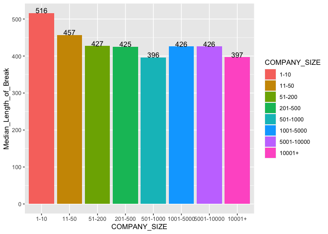

### Top 10 Job Titles

|  | TITLE_NAME | Number | Relative Frequency |
| --- | --- | --- | --- |
| 1 | manager | 6823 | 0.8% |
| 2 | administrator | 6138 | 0.7% |
| 3 | teacher | 5738 | 0.7% |
| 4 | office manager | 5289 | 0.6% |
| 5 | secretary | 5163 | 0.6% |
| 6 | account manager | 4940 | 0.6% |
| 7 | project manager | 4488 | 0.5% |
| 8 | personal assistant | 3956 | 0.5% |
| 9 | solicitor | 3563 | 0.4% |
| 10 | assistant manager | 3325 | 0.4% |

[interactive chart not shown]